# GROUP6REPORT

## Methodology

In our investigation of cognitive abilities, we conducted four distinct tests to gather data on participants’ mathematical, memory, spatial reasoning and number sense aptitudes. In our mathematics ability test, participants were assessed on their problem solving skills, covering addition, subtraction, multiplication, division, square rooting and exponentiation. The questions gradually increased in difficulty. Data collected in this test included participants’ total scores, average response times and total time which helped us to make conclusions into both accuracy and efficiency in mathematical problem-solving. The memory test presented individuals with a grid of coloured shapes, numbers and words, prompting answers alluding to the grid. Data collection encompassed scores and the response times, which helped to provide a perspective on participants' memory recall accuracy and information processing efficiency.

Participants also engaged in a spatial reasoning test that assessed their ability to identify a 2D projection from a 3D prompt. Data collected focused on scores, offering insights into patterns in responses. The ANS test aimed to assess proficiency in working with numerical concepts. Collected data included scores and participant’s sex, allowing for insights into numerical reasoning abilities and potential gender-based comparisons.

## Results and Discussion

### Hypothesis A: Is ANS related to mathematics, spatial reasoning or memory skills?

### Histogram plots of the results from each of the tests conducted, that enable the reader to visualise the results and demonstrate that there are no issues (e.g. outliers).

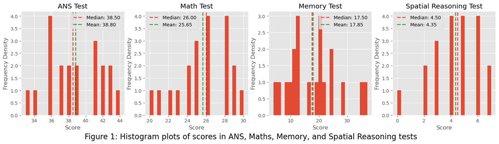

```python
def make_histogram():
    plt.style.use('ggplot')
    fig, axes = plt.subplots(1, 4, figsize=(18, 4))

    for i, (test_name, scores) in enumerate(zip(["ANS", "Math", "Memory", "Spatial Reasoning"],
                                                [score_ans, score_math, score_memory, score_spatial])):
        axes[i].hist(scores, bins=25)
        axes[i].set_title(f"{test_name} Test")
        axes[i].set_xlabel("Score")
        axes[i].set_ylabel("Frequency Density")

        # Add median and mean lines to the plot
        median_val = np.median(scores)
        mean_val = np.mean(scores)

        axes[i].axvline(median_val, color='red', alpha=0.7, linestyle='dashed', linewidth=2, label=f'Median: {median_val:.2f}')
        axes[i].axvline(mean_val, color='green', alpha=0.7, linestyle='dashed', linewidth=2, label=f'Mean: {mean_val:.2f}')
        axes[i].legend()

    # Move the "Figure 1: ..." legend below the entire figure
    fig.text(0.5, -0.05, "Figure 1: Histogram plots of scores in ANS, Maths, Memory, and Spatial Reasoning tests",
             fontsize=16, ha='center', va='center')

    plt.show()

make_histogram()
```

### Three scatter plots showing the ANS scores vs other scores.

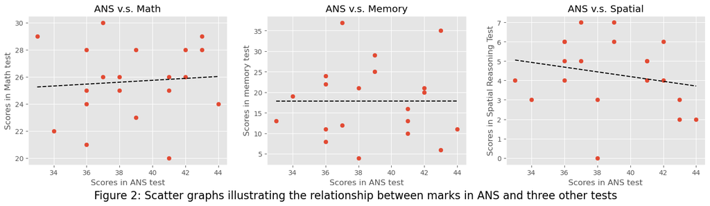

```python
def make_scatter_graph():
    fig = plt.figure(figsize=(18, 4))

    axes1 = plt.subplot(1, 3, 1)
    plt.scatter(score_ans, score_math)
    plt.plot([33, 44], [25.23864, 26.01194], 'k--')
    plt.title("ANS v.s. Math")
    plt.xlabel("Scores in ANS test")
    plt.ylabel("Scores in Math test")

    axes2 = plt.subplot(1, 3, 2)
    plt.scatter(score_ans, score_memory)
    plt.plot([33, 44], [17.83798, 17.86075], 'k--')
    plt.title("ANS v.s. Memory")
    plt.xlabel("Scores in ANS test")
    plt.ylabel("Scores in memory test")

    axes3 = plt.subplot(1, 3, 3)
    plt.scatter(score_ans, score_spatial)
    plt.plot([33, 44], [5.05859, 3.71494], 'k--')
    plt.title("ANS v.s. Spatial")
    plt.xlabel("Scores in ANS test")
    plt.ylabel("Scores in Spatial Reasoning Test")

    fig.text(0.5, -0.05, "Figure 2: Scatter graphs illustrating the relationship between marks in ANS and three other tests",
             fontsize=16, ha='center', va='center')

    plt.show()

# Call the function
make_scatter_graph()
```

### Spearman rank-order method results.

```python
def table_for_measurements():
    data = {
        'Correlation Value': [0.11664, -0.02995, -0.24914],
        'P-value': [ 0.62435, 0.90026, 0.28948]
            }

    index = ['ANS/math test', 'ANS/memory test', 'ANS/spatial reasoning test']
    df = pd.DataFrame(data, index=index)
    print(df)

print("\n Spearman rank-order results\n")
table_for_measurements()
```

```
 Spearman rank-order results

                            Correlation Value  P-value
ANS/math test                         0.11664  0.62435
ANS/memory test                      -0.02995  0.90026
ANS/spatial reasoning test           -0.24914  0.28948
```

**Hypothesis A discussion:**: In Hypothesis A, the null hypothesis is that there is no correlation between each different test, and the alternative hypothesis is that there is a significant correlation between tests. However, neither the scatter plots or the results of the spearman rank-order method showed any significant correlation between each test. The p-values for each comparison were larger than 0.05, indicating that we fail to reject the null hypothesis.

### Hypothesis B: Can we detect any significant difference between the scores of males and females across our cognitive ability tests?

Box plots below (Figure 3) employed to draw conclusions regarding performance differences based on gender.

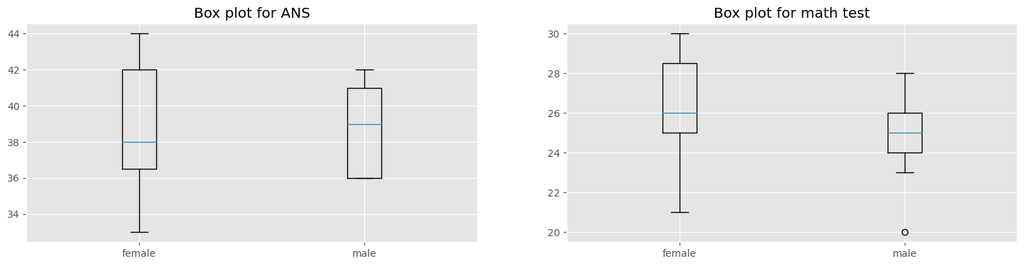

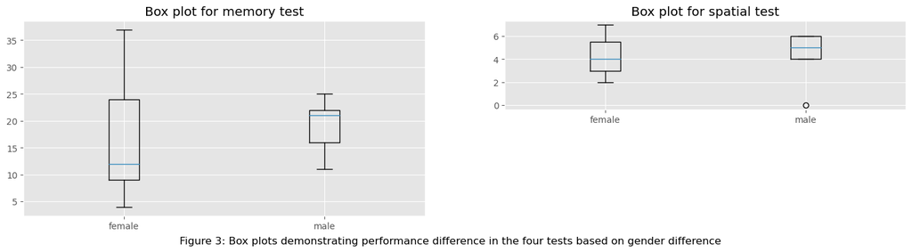

```python
def make_box_plots():

    fig1 = plt.figure(figsize=(18, 4))
    axes1 = plt.subplot(1, 2, 1)
    plt.title("Box plot for ANS")
    my_dict = {'female': ans_female, 'male': ans_male}
    axes1.boxplot(my_dict.values())
    axes1.set_xticklabels(my_dict.keys())

    axes2 = plt.subplot(1, 2, 2)
    plt.title("Box plot for math test")
    my_dict = {'female': math_female, 'male': math_male}
    axes2.boxplot(my_dict.values())
    axes2.set_xticklabels(my_dict.keys())

    fig2 = plt.figure(figsize=(18, 4))
    axes3 = plt.subplot(1, 2, 1)
    plt.title("Box plot for memory test")
    my_dict = {'female': memory_female, 'male': memory_male}
    axes3.boxplot(my_dict.values())
    axes3.set_xticklabels(my_dict.keys())

    axes4 = plt.subplot(2, 2, 2)
    plt.title("Box plot for spatial test")
    my_dict = {'female': spatial_female, 'male': spatial_male}
    axes4.boxplot(my_dict.values())
    axes4.set_xticklabels(my_dict.keys())

    # Adding a caption below the figure
    caption = "Figure 3: Box plots demonstrating performance difference in the four tests based on gender difference"
    plt.figtext(0.5, 0.01, caption, ha='center', va='center', fontsize=12)

    plt.show()

make_box_plots()
```

### T-Test Results

```python
def table_for_Ttest():
    data = {
        'Mean Score Male': [39, 24.89, 19.22, 4.44],
        'SD Male': [2.6, 2.47, 4.84, 1.88],
        'Mean Score Female': [38.64, 26.27, 16.73, 4.27],
        'SD Female': [3.72, 2.94, 11.7, 1.85],
        'Difference in Score': [0.36, -1.38, 2.49, 0.17],
        'p-value': [0.81, 0.28 ,0.56 ,0.84]
           }

    index = ['ANS test', 'Math test', 'Memory test', 'Spatial test']
    df = pd.DataFrame(data, index=index)

    print(df)

print("\n T-test results\n")
table_for_Ttest()
```

```
 T-test results

              Mean Score Male  SD Male  Mean Score Female  SD Female  \
ANS test                39.00     2.60              38.64       3.72
Math test               24.89     2.47              26.27       2.94
Memory test             19.22     4.84              16.73      11.70
Spatial test             4.44     1.88               4.27       1.85

              Difference in Score  p-value
ANS test                     0.36     0.81
Math test                   -1.38     0.28
Memory test                  2.49     0.56
Spatial test                 0.17     0.84
```

### Dot plots exhibiting T-test results by gender

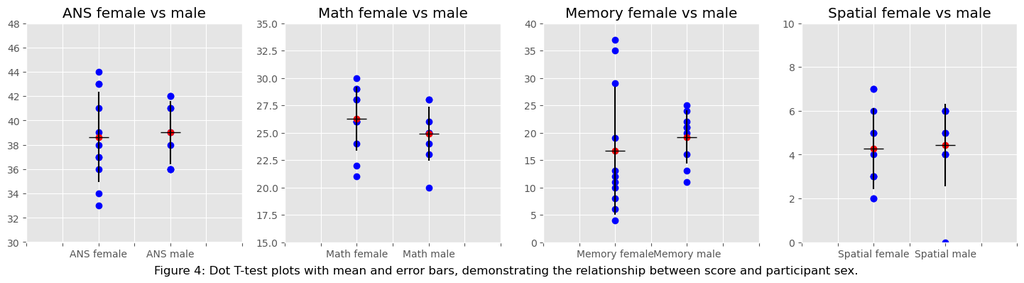

```python
def make_dot_plots():
    fig, axes = plt.subplots(1, 4, figsize=(18, 4))

    # Function to add error bars to the dot plot
    def add_error_bars(ax, x, mean, se):
        ax.errorbar(x, mean, yerr=se, fmt='_', color='black', markersize=20, label='Mean ± SE')

    # Plot for ANS
    axes[0].set_title("ANS female vs male")
    axes[0].set_xlim(0, 3)
    axes[0].set_ylim(30, 48)
    axes[0].plot(number_female, ans_female, 'bo')
    axes[0].plot(1, 38.64, 'ro')
    axes[0].plot(number_male, ans_male, 'bo')
    axes[0].plot(2, 39, 'ro')
    add_error_bars(axes[0], [1, 2], [38.64, 39], [3.72, 2.6])
    axes[0].set_xticks([0, 0.5, 1, 1.5, 2, 2.5, 3], ['', '', 'ANS female', '', 'ANS male', '', ''])

    # Plot for Math
    axes[1].set_title("Math female vs male")
    axes[1].set_xlim(0, 3)
    axes[1].set_ylim(15, 35)
    axes[1].plot(number_female, math_female, 'bo')
    axes[1].plot(1, 26.27, 'ro')
    axes[1].plot(number_male, math_male, 'bo')
    axes[1].plot(2, 24.89, 'ro')
    add_error_bars(axes[1], [1, 2], [26.27, 24.89], [2.94, 2.47])
    axes[1].set_xticks([0, 0.5, 1, 1.5, 2, 2.5, 3], ['', '', 'Math female', '', 'Math male', '', ''])

    # Plot for Memory
    axes[2].set_title("Memory female vs male")
    axes[2].set_xlim(0, 3)
    axes[2].set_ylim(0, 40)
    axes[2].plot(number_female, memory_female, 'bo')
    axes[2].plot(1, 16.73, 'ro')
    axes[2].plot(number_male, memory_male, 'bo')
    axes[2].plot(2, 19.22, 'ro')
    add_error_bars(axes[2], [1, 2], [16.73, 19.22], [11.7, 4.84])
    axes[2].set_xticks([0, 0.5, 1, 1.5, 2, 2.5, 3], ['', '', 'Memory female', '', 'Memory male', '', ''])

    # Plot for Spatial
    axes[3].set_title("Spatial female vs male")
    axes[3].set_xlim(0, 3)
    axes[3].set_ylim(0, 10)
    axes[3].plot(number_female, spatial_female, 'bo')
    axes[3].plot(1, 4.27, 'ro')
    axes[3].plot(number_male, spatial_male, 'bo')
    axes[3].plot(2, 4.44, 'ro')
    add_error_bars(axes[3], [1, 2], [4.27, 4.44], [1.85, 1.88])
    axes[3].set_xticks([0, 0.5, 1, 1.5, 2, 2.5, 3], ['', '', 'Spatial female', '', 'Spatial male', '', ''])

    caption = "Figure 4: Dot T-test plots with mean and error bars, demonstrating the relationship between score and participant sex."
    plt.figtext(0.5, 0.01, caption, ha='center', va='center', fontsize=12)

    # Show plot
    plt.show()

make_dot_plots()
```

**Hypothesis B discussion:**: In hypothesis B, the null hypothesis is that there is no significant difference in any of the tests in terms of the sex of the participant.The alternative hypothesis is that there is a significant difference between genders. T-test results in p-values all larger than 0.05. Therefore, we fail to reject the null hypothesis. This means that gender has no significant effect on the performance in different cognitive tests.

## Summary and outlook:

Although our study remained inconclusive, there were many reasons which could have led to this ambiguity. Researchers should aim to refine and improve the methods used. If a correlation is seen, findings and conclusions can be used in a variety of ways. For example, in the case that a correlation is found, it can act as a key starting point in understanding the cognitive mechanisms associated with doing each individual test and understanding if there are any shared components. In the case that a correlation is found, assessing someone's cognitive ability would have to be done through the completion of various linked tests as it would give a more holistic overview of one's cognitive capabilities. This has many implications in employment as well as education. For instance, the results of these tests can be taken into account during formation of educational approaches and programs, making them more adapted for each individual. Additionally, we could possibly aim to improve one's ability in completing an ANS task in order to improve their overall cognitive abilities. Similarly, finding sex differences in regards to cognition can help various students, as it could lead to more tailored support in certain areas of education.

## Bibliography

[Blasiman, R.N. and Was, C.A. (2018)](https://doi.org/10.5964/ejop.v14i1.1472) Why Is Working Memory Performance Unstable? A Review of 21 Factors. Europe’s Journal of Psychology, [online] 14(1), pp.188–231. doi:https://doi.org/10.5964/ejop.v14i1.1472.

[Bonny, J.W. and Lourenco, S.F. (2013)](https://doi.org/10.1016/j.jecp.2012.09.015) The approximate number system and its relation to early math achievement: Evidence from the preschool years. Journal of Experimental Child Psychology, [online] 114(3), pp.375–388. doi:https://doi.org/10.1016/j.jecp.2012.09.015.

[Voyer, D., Voyer, S., and Bryden, M.P. (1995)](https://doi.org/10.1037/0033-2909.117.2.250) Magnitude of sex differences in spatial abilities: A meta-analysis and consideration of critical variables. Psychological Bulletin, 117(2), pp.250–270. doi:https://doi.org/10.1037/0033-2909.117.2.250.

[Felson, R.B. and Trudeau, L. (1991)](https://doi.org/10.2307/2786930) Gender Differences in Mathematics Performance. Social Psychology Quarterly, 54(2), pp. 113-126.

[Vos, H., Marinova, M., De Leon, S.C., Sasanguie, D. and Reynvoet, B. (2023)](https://doi.org/10.1016/j.lindif.2022.102255) Gender differences in young adults' mathematical performance: Examining the contribution of working memory, math anxiety and gender-related stereotypes. Learning and Individual Differences, 102(102255)